# Dead/Live Organoid Classification (Human)

Jan Sauer

27.10.2017

```r
library(PROMISE)
library(ggplot2)
library(reshape2)

# Directories and files
# config_dir = "/collab-ag-fischer/PROMISE/data-10x-4t-c-16z/configdir"
config_dir = "/local-collab-ag-fischer/PROMISE/data-10x-4t-c-16z/configdir"
# data_dir = "/Users/jansauer/Thesis/Projects/PROMISE/FeatureAnalysis/organoid_classifier/data"
data_dir = "/Users/jansauer/Thesis/Projects/PROMISE/FeatureAnalysis/python_package/dead_organoid_classifier"
source(file.path(config_dir, "watchdogConfig.R"))
```

# Introduction

I trained a random forest classifier on live and dead objects using positive (Bortezomib and Irinotecan/SN-38 @ 0.2 and 1.0) and negative control wells (DMSO). I then applied this classifier to the entire screen to determine how many dead and live organoids are in each well. The organoid features were preprocessed by normalizing them to the DMSO values to remove any plate effects:

$$feature = \frac{feature - median_{DMSO}}{MAD_{DMSO}}$$

The resulting features are therefor a measure of the deviation from the DMSO controls that can be compared across plates and cell lines due to the MAD scaling.

The classifier was trained for each cell line individually. The preprocessing and the training of the classifiers was done in a python script. Shown here are the results.

```r
all_plates = sort(list.files(path = data_dir, pattern = "^D0"))
all_plates = sort(unique(substr(all_plates, 1, 14)))

# Use only plates that haven't been reimaged
use_plates = c()
for(plate in all_plates) {
  reimaged_flag = ifelse(test = substr(plate, 9, 9) == "9", yes = TRUE, no = FALSE)
  if(reimaged_flag) {
    use_plates = c(use_plates, TRUE)
    next
  }
  reimaged = plate
  substr(reimaged, 9, 9) = "9"
  use_plates = c(use_plates, ifelse(
    test = reimaged %in% all_plates,
    yes = FALSE, no = TRUE))
}
all_plates = sort(all_plates[use_plates])

# Load data
mortality = list()
for(plate in all_plates) {
  # dat = read.csv(file.path(data_dir, plate, sprintf("%s_organoid_classification.csv", plate)))
  dat = read.csv(file.path(data_dir, sprintf("%s_organoid_classification.csv", plate)))
  rownames(dat) = paste0(plate, "_", substr(dat$Well.ID, 1, 1), "_", substr(dat$Well.ID, 2, 3))
  dat$X = NULL
  mortality[[plate]] = dat
}
mortality = do.call(rbind, mortality)
rownames(mortality) = sapply(strsplit(rownames(mortality), ".", fixed = TRUE), "[[", 2)
```

Keep only wells with replicates

```r
rep_id = paste0(substr(rownames(mortality), 1, 7), "_", substr(rownames(mortality), 12, 19))
wells_to_keep = names(which(table(rep_id) == 2))
mortality = mortality[rep_id %in% wells_to_keep, ]
```

# Classifier Verification

There are three steps to showing that the classifier does actually differentiate between live and dead cells. For this verification I do not differentiate between cell lines as the ratios of dead cells should, in princple, be directly comparable.

## Training Set Verification

First, I look at the training data, the positive and negative controls mentioned above, and confirm that these are all classified correctly. A look at the (nearly degenerate) violin plot shows that both positive and negative controls are overwhelmingly correctly predicted. As expected, the negative control wells exhibit a larger range of dead organoid fractions. This is because organoids do die off naturally in some cases. In particular, this shows the robustness of the classifier with regards to partially incorrectly labelled training data.

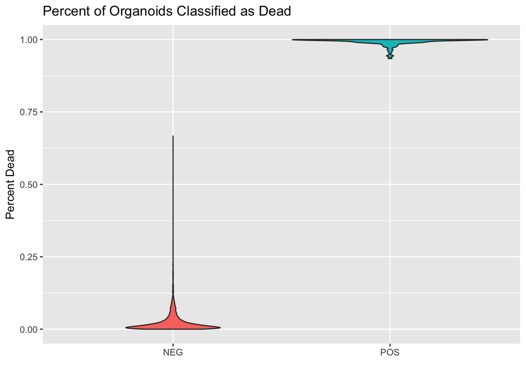

```r
pos_ctrls = mortality[
  mortality$Product.Name %in% c("Bortezomib", "Irinotecan / SN-38") &
  mortality$concentration %in% c(0.2, 1.0), ]

neg_ctrls = mortality[
  mortality$Product.Name %in% c("DMSO"), ]

ggplotdf = data.frame(
  "Percent.Dead" = c(pos_ctrls$Percent.Dead, neg_ctrls$Percent.Dead),
  "Control" = rep(c("POS", "NEG"), c(nrow(pos_ctrls), nrow(neg_ctrls))))

ggplot(data = ggplotdf) + geom_violin(aes(x = Control, y = Percent.Dead, fill = Control)) +
  theme(legend.position = "none") + ggtitle("Percent of Organoids Classified as Dead") +
  xlab("") + ylab("Percent Dead")
```

```r
most_dead_dmso = strsplit(
  rownames(neg_ctrls[which.max(neg_ctrls$Percent.Dead),]),
  "_")[[1]]

most_dead_dmso_fn = thumbnailFilename(
  filedir = file.path(htmldir, most_dead_dmso[[1]]),
  platename = most_dead_dmso[[1]], row = most_dead_dmso[[2]],
  col = most_dead_dmso[[3]], configdir = config_dir, level = 1,
  addPath = TRUE)
```

The “most dead” DMSO well is pictured here.

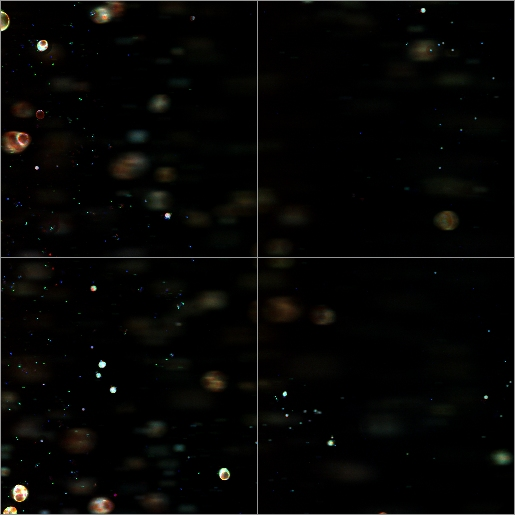

## Positive Control Gradients

The classifier was trained on concentrations of 0.2 and 1.0 of both Bortezomib and Irinotecan / SN-38. Both of these concentrations led to a complete death of all organoids in the wells. As a second verification step, I take a look at the lower concentrations of these two drugs.

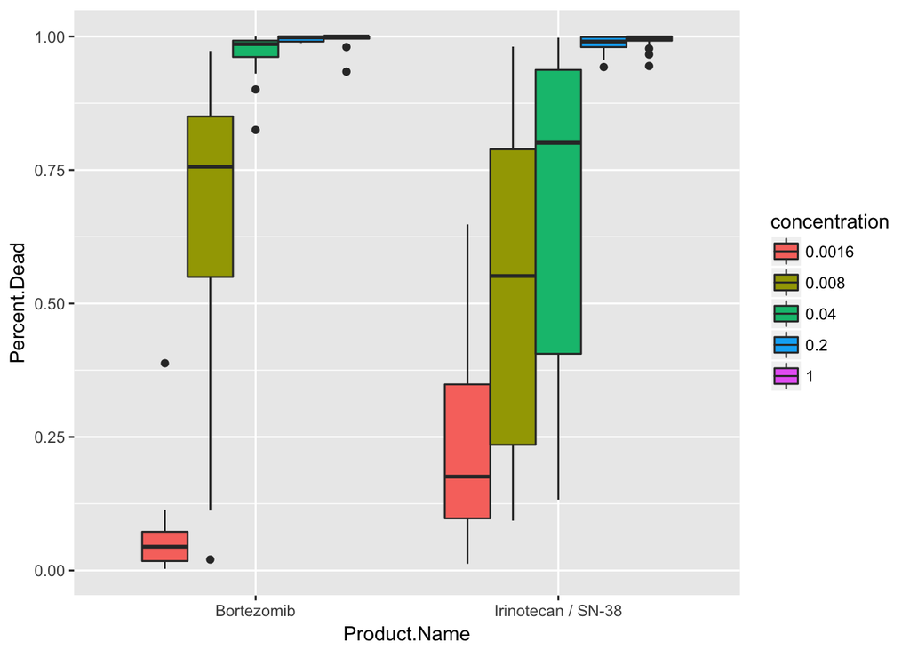

```r
pos_ctrls = mortality[mortality$Product.Name %in% c("Bortezomib", "Irinotecan / SN-38"),]
pos_ctrls$concentration = as.factor(pos_ctrls$concentration)
ggplot(data = pos_ctrls) + geom_boxplot(aes(x = Product.Name, y = Percent.Dead, fill = concentration))
```

```r
# Test correlation
pos_ctrls = mortality[
  mortality$Product.Name %in% c("Bortezomib", "Irinotecan / SN-38"),
  c("concentration", "Percent.Dead")]
correlation = cor(
  pos_ctrls$concentration, pos_ctrls$Percent.Dead,
  use = "pairwise.complete.obs", method = "spearman")
```

The fraction of dead organoids correlates strongly with the concentration of the positive controls ($\rho$ = 0.8596125). I used the rank-based spearman correlation as the concentrations are on a logarithmic scale and I am more interested in the common trend rather than an actual, linear relationship between the two.

## Replicate similarity

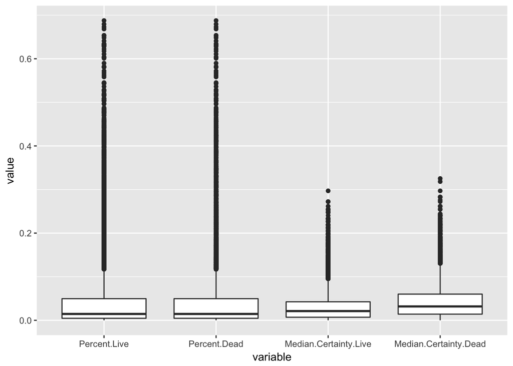

```r
wells_id = paste0(
  substr(rownames(mortality), 1, 7), "_",
  substr(rownames(mortality), 12, 19))

# Drop any wells without a replicate
mortality_rep = mortality[
  wells_id %in% names(which(table(wells_id) == 2)), ]
wells_id = paste0(
  substr(rownames(mortality_rep), 1, 7), "_",
  substr(rownames(mortality_rep), 12, 19))

mortality_agg = mortality_rep[,c(
  "Percent.Live", "Percent.Dead",
  "Median.Certainty.Live", "Median.Certainty.Dead")]
mortality_agg = aggregate(mortality_agg, list(wells_id), function(x) sd(x))
rownames(mortality_agg) = mortality_agg$Group.1
mortality_agg$Group.1 = NULL

mortality_agg = melt(mortality_agg)
mortality_agg = mortality_agg[is.finite(mortality_agg$value), ]
ggplot(data = mortality_agg) + geom_boxplot(aes(x = variable, y = value))
```

# Staurosporine Wells

An interesting pseudo-validation of the method is to look at the effect that Staurosporine has on each cell line. We confirmed visually that the Staurosporine concentration was too low and the cell lines reacted to varying degrees to it. The ratios of dead to live organoids as detected by the classifier matches our visual assessment.

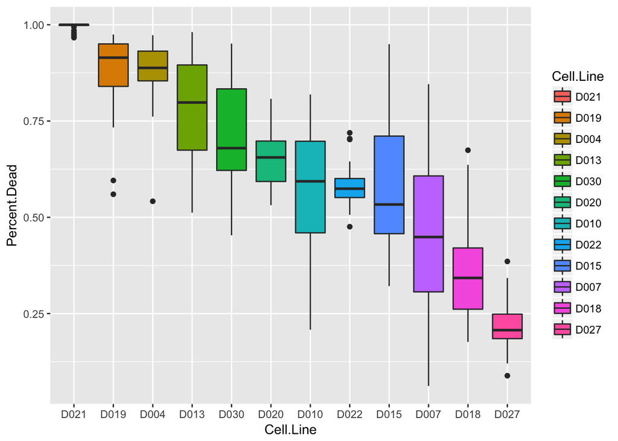

```r
stauro_wells = mortality[
  mortality$Product.Name %in% c("Staurosporine_500nM"),
  c("Percent.Dead"), drop=FALSE]
stauro_wells$Cell.Line = substr(rownames(stauro_wells), 1, 4)
stauro_cl_medians = aggregate(
  stauro_wells$Percent.Dead,
  list(stauro_wells$Cell.Line), median)
ggplot_levels = stauro_cl_medians$Group.1[order(stauro_cl_medians$x, decreasing = TRUE)]
stauro_wells$Cell.Line = factor(stauro_wells$Cell.Line, levels = ggplot_levels)
ggplot(data = stauro_wells) + geom_boxplot(aes(x = Cell.Line, y = Percent.Dead, fill = Cell.Line))
```

# Differential Treatments

I am interested in treatments that lead to individual differences between cell lines. For simplicity’s sake, I only look at plates with layouts L02 and L03.

```r
layout_id = substr(rownames(mortality), 12, 14)
mortality_l02l03 = mortality[layout_id %in% c("L02", "L03"), ]
```

I’m interested in treatments that have differential effects between cell lines. As a first step, I look at how stable the effect of treatments is between replicates. I look at the difference of the values of percent dead organoids between the two replicates. As seen in the histogram, most wells and their replicates show stable behaviour with regard to organoid death.

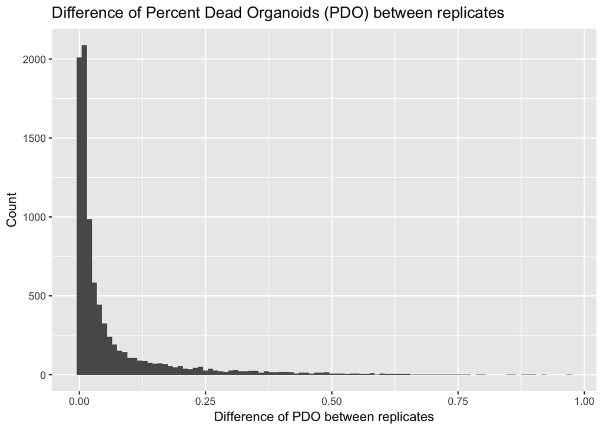

```r
rep_id = paste0(
  substr(rownames(mortality_l02l03), 1, 7), "_",
  substr(rownames(mortality_l02l03), 12, 19))
mortality_l02l03_agg = aggregate(
  mortality_l02l03[, "Percent.Dead", drop=FALSE],
  list(rep_id), function(x) diff(range(x, na.rm = TRUE)))
ggplot(data = mortality_l02l03_agg) + geom_histogram(aes(x = Percent.Dead), binwidth = 0.01) +
  xlab("Difference of PDO between replicates") + ylab("Count") +
  ggtitle("Difference of Percent Dead Organoids (PDO) between replicates")
```

A look at the “worst” well pair shows that this is due to the combination of poor image quality and resulting poor segmentation.

Classified as Alive (D030T01P002L03_G_02)

Classified as Dead (D030T01P906L03_G_02)

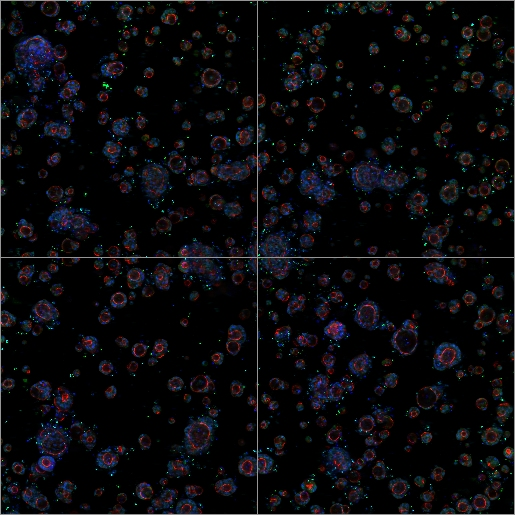

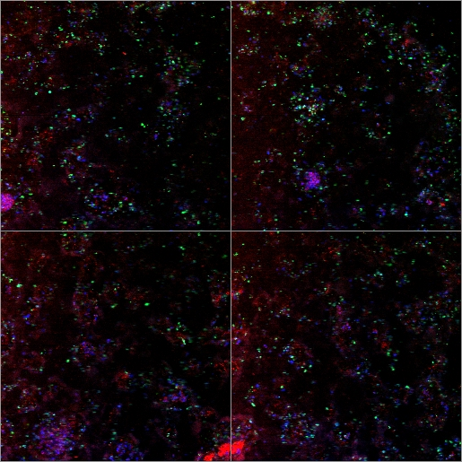

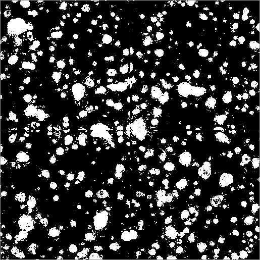

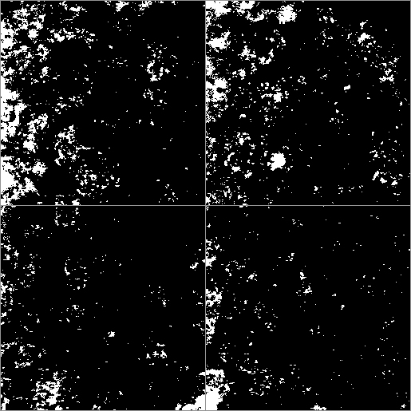

I keep only treatments that have reasonably consistent effects on the replicates, i.e. a difference of dead organoid percentage of <= 25% between replicates.

```r
good_wells = mortality_l02l03_agg[mortality_l02l03_agg$Percent.Dead <= 0.25, "Group.1"]
mortality_l02l03 = mortality_l02l03[rep_id %in% good_wells, ]
```

Next, I look at which treatments have a differential effect between cell lines. For this, I look at the range of the number of killed organoids for each treatment across cell lines. A look at these ranges shows that there are a number of treatments with a stable effect that show a substantial difference in their killing effect between cell lines.

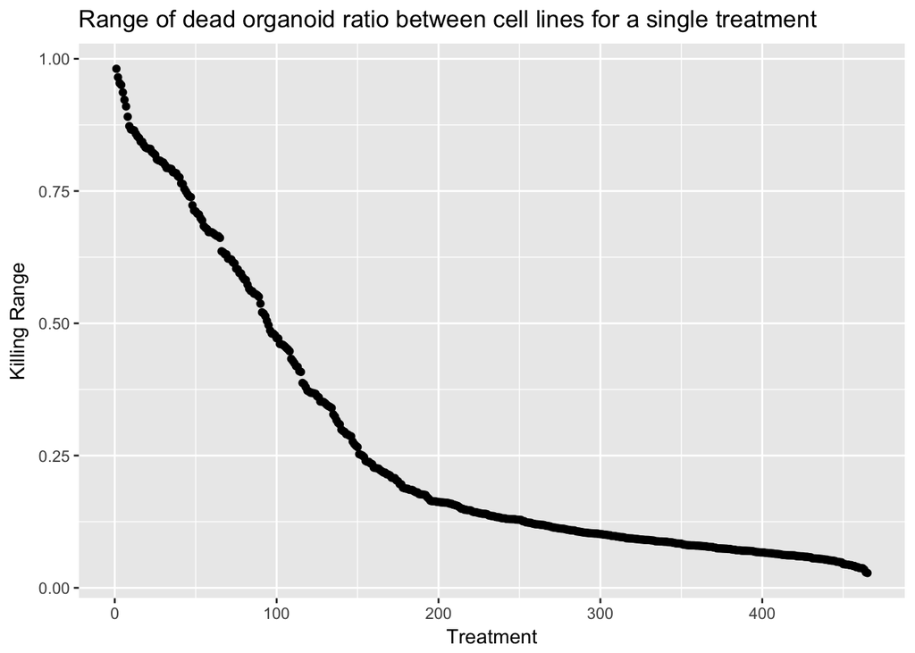

```r
mortality_l02l03_agg = aggregate(
  mortality_l02l03[,"Percent.Dead", drop=FALSE],
  list(substr(rownames(mortality_l02l03), 1, 7), mortality_l02l03$Product.Name),
  mean)

effect_range_per_treatment = aggregate(
  mortality_l02l03_agg[, "Percent.Dead", drop=FALSE],
  list(mortality_l02l03_agg$Group.2),
  function(x) diff(range(x, na.rm = TRUE)))

effect_range_per_treatment = effect_range_per_treatment[
  order(effect_range_per_treatment$Percent.Dead, decreasing = TRUE), ]
effect_range_per_treatment$x = seq_len(nrow(effect_range_per_treatment))

ggplot(data = effect_range_per_treatment) + geom_point(aes(x = x, y = Percent.Dead)) +
  xlab("Treatment") + ylab("Killing Range") +
  ggtitle("Range of dead organoid ratio between cell lines for a single treatment")
```

I plot the top three treatments below as an example.

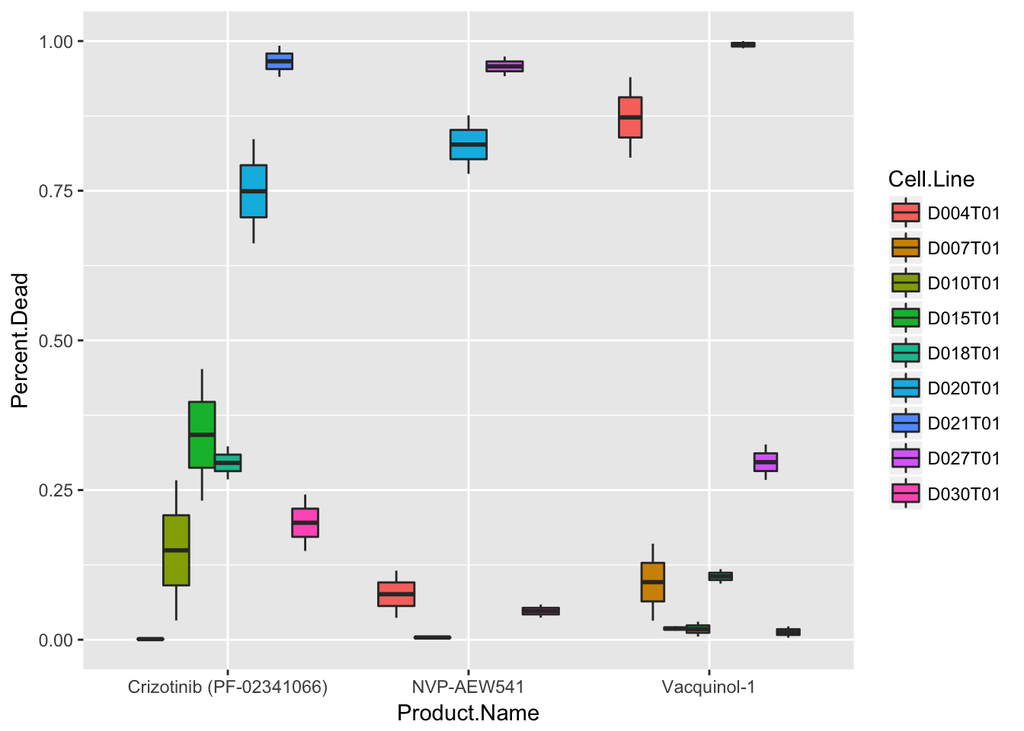

```r
top_treatments = as.character(effect_range_per_treatment$Group.1[1:3])
ggplotdf = mortality_l02l03[mortality_l02l03$Product.Name %in% top_treatments, ]
ggplotdf$Cell.Line = substr(rownames(ggplotdf), 1, 7)
ggplot(data = ggplotdf) + geom_boxplot(aes(x = Product.Name, y = Percent.Dead, fill = Cell.Line))
```

From these three treatments alone it is clear that certain patients react much more strongly to treatments than others. A followup analysis could attempt to find common genetic markers in patients that react similarly to treatments to determine potential gene-drug interactions.